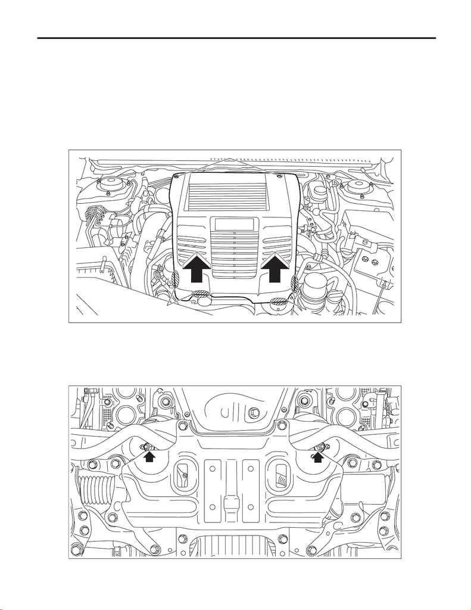

LU(w/o STI)-14

Oil Pan and Strainer

LUBRICATION

5. Oil Pan and Strainer

A: REMOVAL

1. OIL PAN AND STRAINER

1) Remove the striker - front hood. <Ref. to EB-11, DISASSEMBLY, Front Hood.>

2) Fully open the front hood. <Ref. to NT-20, FRONT HOOD DAMPER STAY, NOTE, Note.>

3) Remove the collector cover.

(1) Remove the clips (A).

(2) Hold the shaded area (B) by hand and carefully pull the RH side (C) upward.

(3) Hold the shaded area (D) by hand and carefully pull the LH side (E) upward.

4) Disconnect the ground terminal from battery sensor. <Ref. to NT-5, BATTERY, NOTE, Note.>

5) Remove the air intake duct. <Ref. to IN(w/o STI)-22, REMOVAL, Air Intake Duct.>

6) Remove the under cover. <Ref. to EI-21, REMOVAL, Front Under Cover.>

7) Drain the engine oil. <Ref. to LU(w/o STI)-11, REPLACEMENT, Engine Oil.>

8) Remove the front exhaust pipe. <Ref. to EX(w/o STI)-9, REMOVAL, Front Exhaust Pipe.>

9) Remove the nuts which secure the engine mounting to the front crossmember.

10) Lower the vehicle.

EX-03204

(A)

(B)

(C)

(E)

(D)

ME-07228

15WRX_STI_US_EN.book 14 ページ ２０１５年２月１３日 金曜日 午前１１時２０分

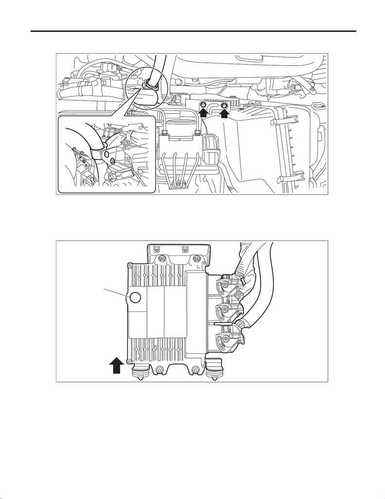

LU(w/o STI)-15

Oil Pan and Strainer

LUBRICATION

11) Remove the clips (A) and (B) which secure the engine harness and bulkhead harness to the bracket, and

remove the bolt which secures the engine control module (ECM) to the bracket.

12) Pull out the engine control module (ECM) from the bracket, and move it to a location that does not inter-

fere operation.

NOTE:

When performing the pulling out operation, pay attention not to apply excessive load to the breather filter por-

tion (a) in order to avoid the damage.

13) Remove the intercooler. <Ref. to IN(w/o STI)-38, REMOVAL, Intercooler.>

IN-03579

(B)

(A)

IN-03580

(a)

15WRX_STI_US_EN.book 15 ページ ２０１５年２月１３日 金曜日 午前１１時２０分

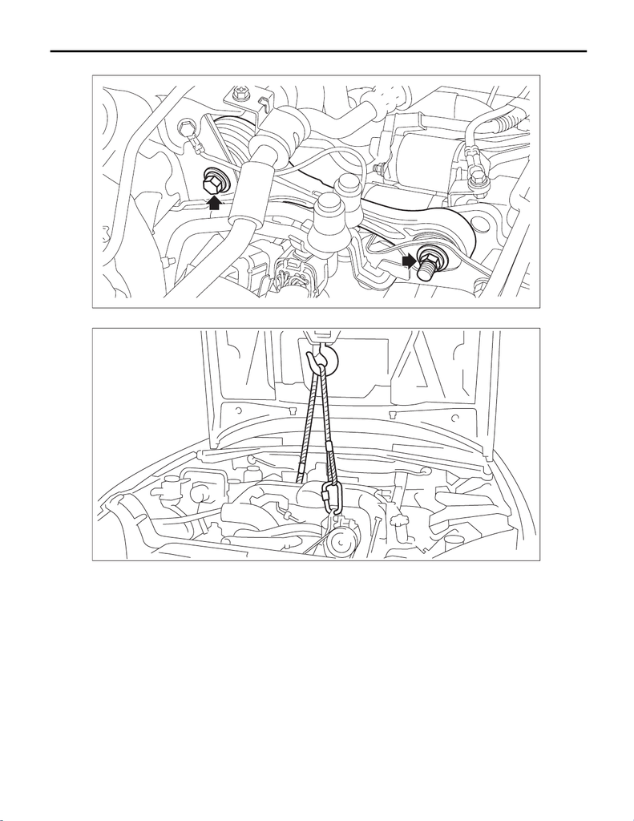

LU(w/o STI)-16

Oil Pan and Strainer

LUBRICATION

14) Remove the pitching stopper.

15) Support the engine with a lifting device and wire ropes.

ME-07877

ME-05105

15WRX_STI_US_EN.book 16 ページ ２０１５年２月１３日 金曜日 午前１１時２０分

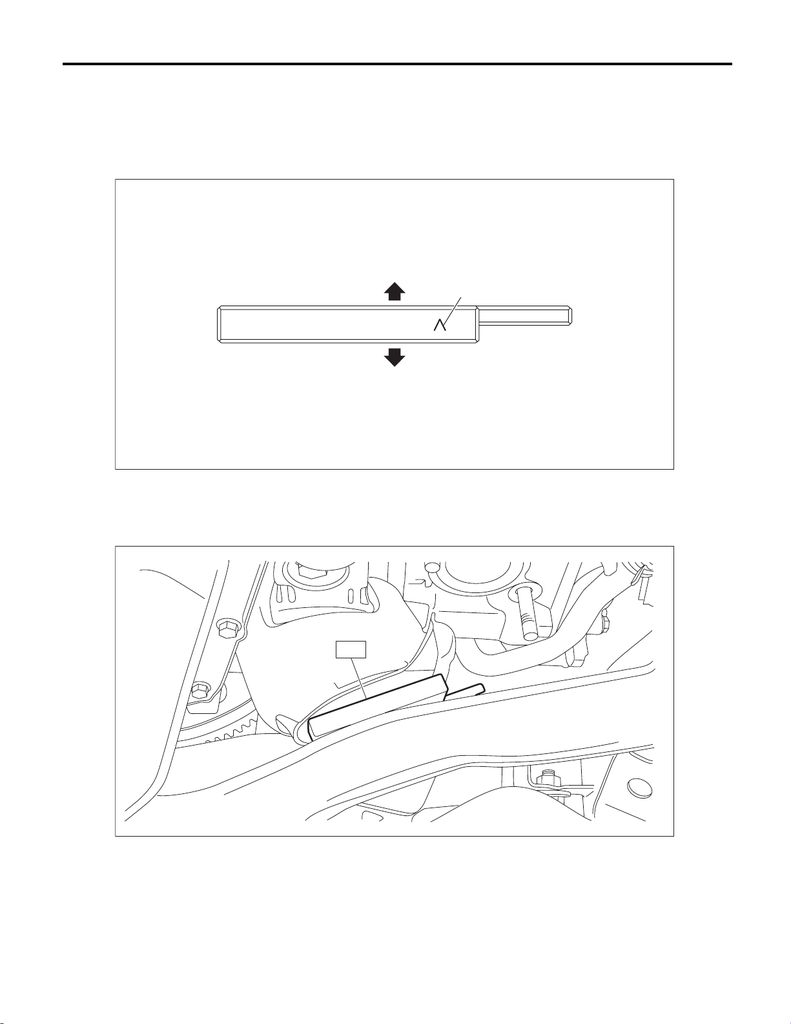

LU(w/o STI)-17

Oil Pan and Strainer

LUBRICATION

16) While gradually lifting up the engine, set the ST between the engine mount LH and crossmember, and

then slowly lower the engine.

CAUTION:

• When lifting up the engine, pay attention to the clearance of each part and be careful not to lift the

engine too much, in order to prevent damaging the vehicle.

• To avoid the damage, be sure to set the ST as shown in the figure.

• After lowering the engine, check that the ST does not come off even if the engine is bounced.

ST 18632AA030 STAND ASSY

(A) Direction mark (B) Engine mounting side (C) Crossmember side

ME-07930

(A)

(B)

(C)

LU-03208

ST

15WRX_STI_US_EN.book 17 ページ ２０１５年２月１３日 金曜日 午前１１時２０分

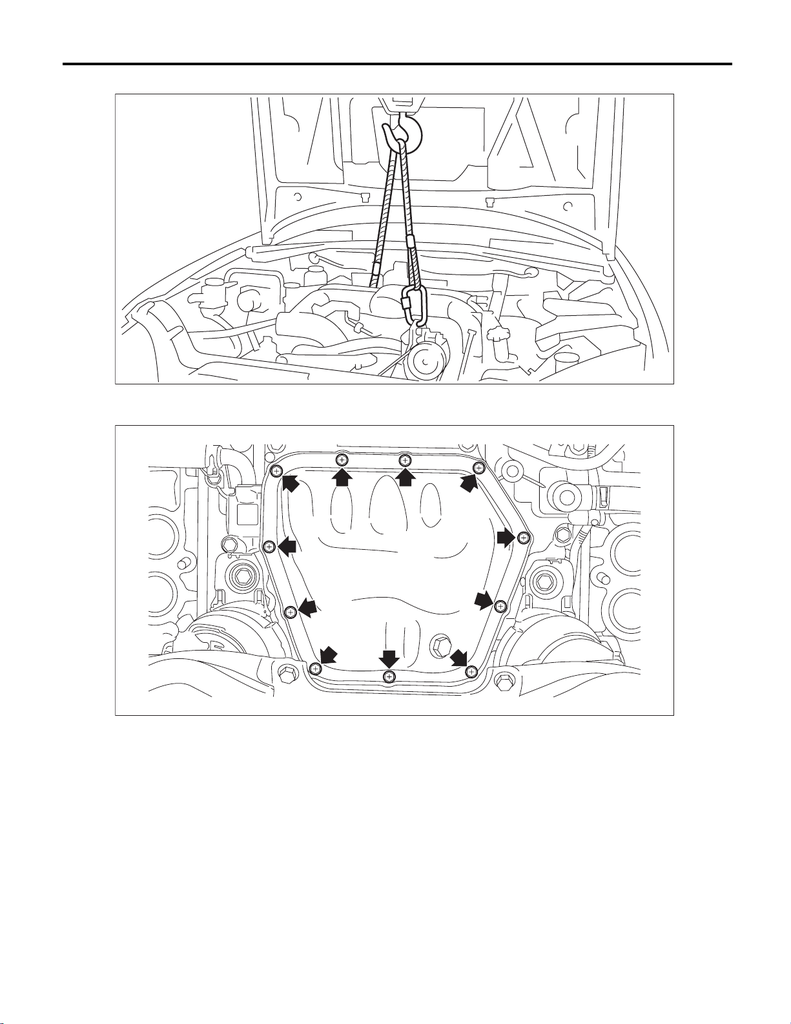

LU(w/o STI)-18

Oil Pan and Strainer

LUBRICATION

17) Remove the lifting device and wire ropes.

18) Lift up the vehicle.

19) Remove the bolts which secure oil pan to oil pan upper.

20) Insert an oil pan cutter blade into the gap between oil pan upper and oil pan, and remove the oil pan.

CAUTION:

Do not use a screwdriver or similar tool in place of oil pan cutter.

ME-05105

LU-03193

15WRX_STI_US_EN.book 18 ページ ２０１５年２月１３日 金曜日 午前１１時２０分

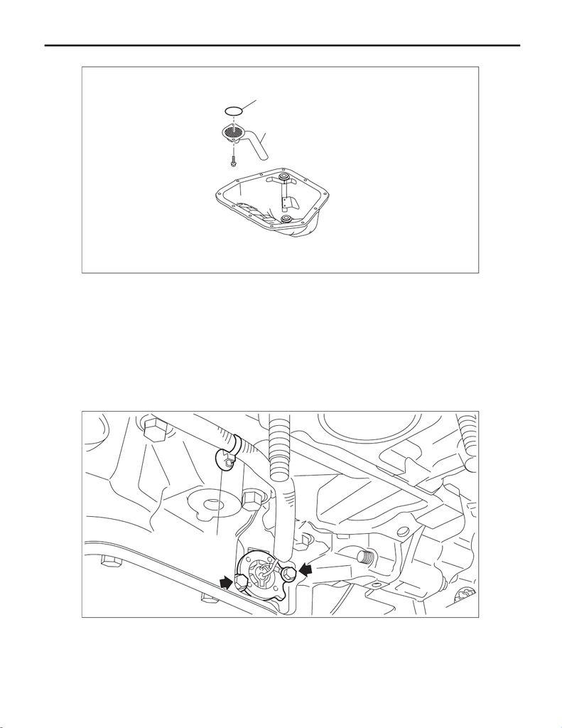

LU(w/o STI)-19

Oil Pan and Strainer

LUBRICATION

21) Remove the oil strainer from the oil pan upper.

2. OIL PAN UPPER

1) Remove the engine from the vehicle. <Ref. to ME(w/o STI)-48, REMOVAL, Engine Assembly.>

2) Remove the water pump. <Ref. to CO(w/o STI)-16, REMOVAL, Water Pump.>

3) Remove the thermostat cover. <Ref. to CO(w/o STI)-33, REMOVAL, Thermostat.>

4) Remove the water pipe assembly. <Ref. to CO(w/o STI)-19, REMOVAL, Water Pipe Assembly.>

5) Remove the chain cover. <Ref. to ME(w/o STI)-93, REMOVAL, Chain Cover.>

6) Remove the oil pan and strainer. <Ref. to LU(w/o STI)-14, OIL PAN AND STRAINER, REMOVAL, Oil Pan

and Strainer.>

7) Remove clip (A) from the oil pan upper, and remove the oil level switch.

(A) Oil strainer (B) O-ring

LU-03217

(A)

(B)

LU-02912

(A)

15WRX_STI_US_EN.book 19 ページ ２０１５年２月１３日 金曜日 午前１１時２０分

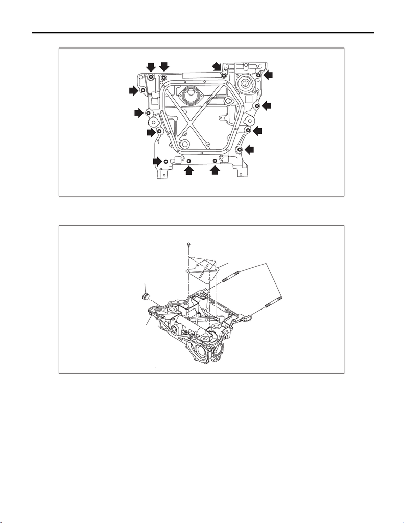

LU(w/o STI)-20

Oil Pan and Strainer

LUBRICATION

8) Remove the bolts which secure oil pan upper to cylinder block, and remove the oil pan upper.

9) Remove the baffle plate from the oil pan upper.

10) Remove stud bolts from the oil pan upper.

11) Remove the plug from the oil pan upper.

(A) Oil pan upper (B) Baffle plate (C) Stud bolt

(D) Plug

LU-02747

LU-03210

(B)

(C)

(A)

(D)

15WRX_STI_US_EN.book 20 ページ ２０１５年２月１３日 金曜日 午前１１時２０分

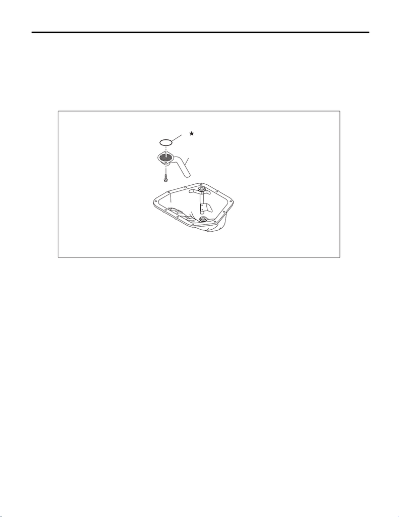

LU(w/o STI)-21

Oil Pan and Strainer

LUBRICATION

B: INSTALLATION

1. OIL PAN AND STRAINER

1) Attach the oil strainer to the oil pan upper.

NOTE:

Use new O-rings.

Tightening torque:

6.4 N·m (0.7 kgf-m, 4.7 ft-lb)

(A) Oil strainer (B) O-ring

LU-03215

(A)

(B)

15WRX_STI_US_EN.book 21 ページ ２０１５年２月１３日 金曜日 午前１１時２０分

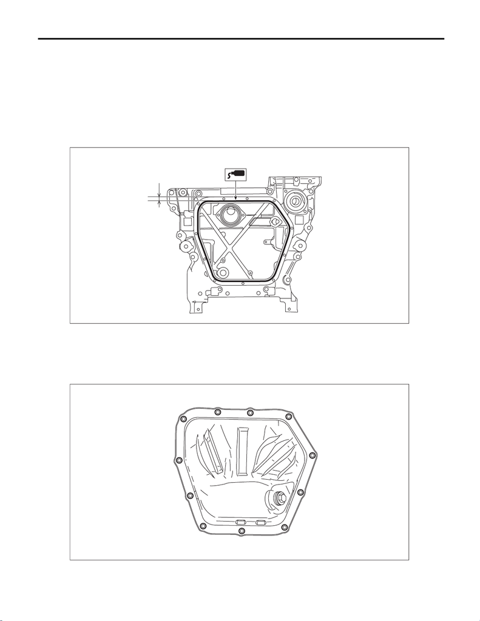

LU(w/o STI)-22

Oil Pan and Strainer

LUBRICATION

2) Apply liquid gasket to the mating surfaces of oil pan upper, and install the oil pan.

NOTE:

• Before installing the oil pan, wipe and clean the mating surface of oil pan and oil pan upper.

• Use a new oil pan seal ring.

• Install within 5 min. after applying liquid gasket.

Liquid gasket:

THREE BOND 1217G (Part No. K0877Y0100) or equivalent

Liquid gasket applying diameter:

5

±

1 mm (0.1969

±

0.0394 in)

3) Tighten the bolts to secure the oil pan to the oil pan upper in the numerical order.

Tightening torque:

6.4 N·m (0.7 kgf-m, 4.7 ft-lb)

4) Lower the vehicle.

(A) 9.5 mm (0.374 in)

LU-02734

(A)

LU-02735

(10)

(1)

(2)

(3)

(4)

(5)

(6)

(7)

(8)

(9)

(11)

15WRX_STI_US_EN.book 22 ページ ２０１５年２月１３日 金曜日 午前１１時２０分

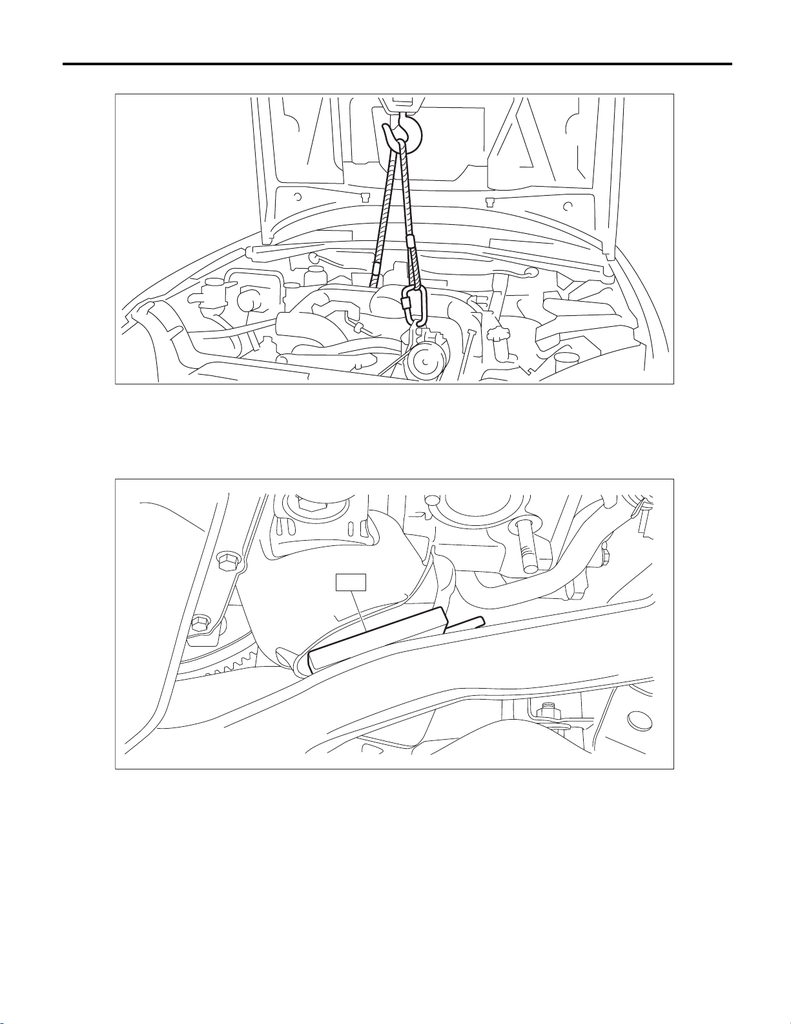

LU(w/o STI)-23

Oil Pan and Strainer

LUBRICATION

5) Support the engine with a lifting device and wire ropes.

6) Lift the engine a little, and remove the ST.

CAUTION:

When lifting up the engine, pay attention to the clearance of each part and be careful not to lift the en-

gine too much, in order to prevent damaging the vehicle.

ST 18632AA030 STAND ASSY

ME-05105

LU-03208

ST

15WRX_STI_US_EN.book 23 ページ ２０１５年２月１３日 金曜日 午前１１時２０分

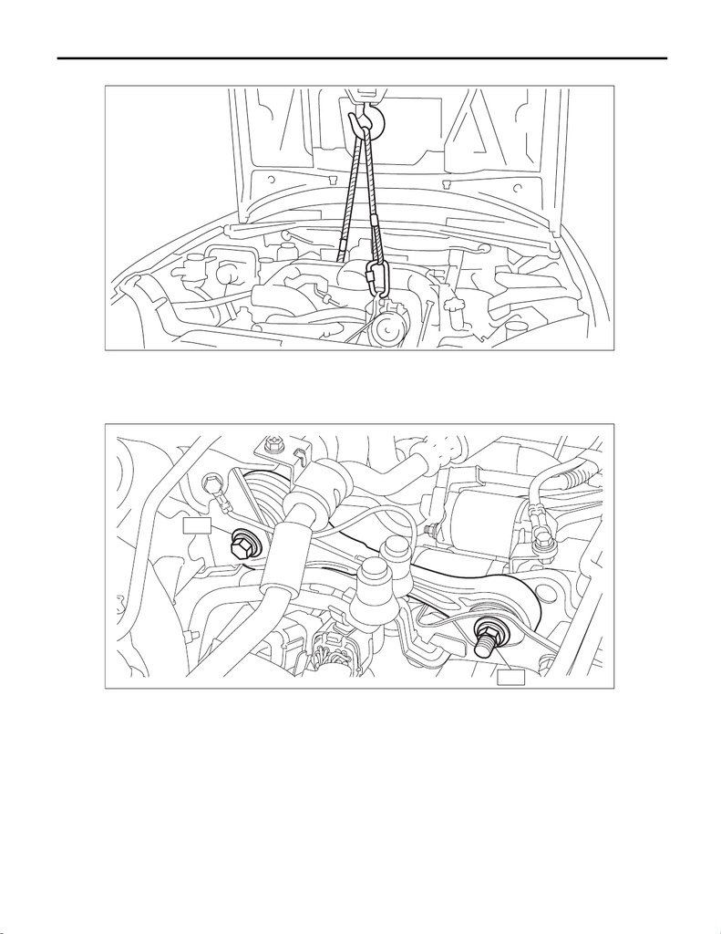

LU(w/o STI)-24

Oil Pan and Strainer

LUBRICATION

7) Lower the engine and remove the lifting device and wire ropes.

8) Install the pitching stopper.

Tightening torque:

T1: 50 N·m (5.1 kgf-m, 36.9 ft-lb)

T2: 58 N·m (5.9 kgf-m, 42.8 ft-lb)

9) Install the intercooler. <Ref. to IN(w/o STI)-41, INSTALLATION, Intercooler.>

ME-05105

ME-07917

T2

T1

15WRX_STI_US_EN.book 24 ページ ２０１５年２月１３日 金曜日 午前１１時２０分

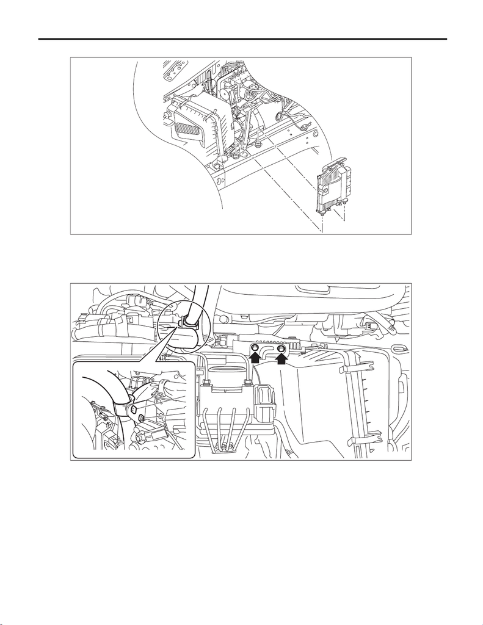

LU(w/o STI)-25

Oil Pan and Strainer

LUBRICATION

10) Insert the engine control module (ECM) to the bracket.

11) Install the bolt which secures the engine control module (ECM) to the bracket, and then secure the en-

gine harness and bulkhead harness to the bracket with clips (A) and (B).

Tightening torque:

7.5 N·m (0.8 kgf-m, 5.5 ft-lb)

12) Lift up the vehicle.

FU-08492

IN-03579

(B)

(A)

15WRX_STI_US_EN.book 25 ページ ２０１５年２月１３日 金曜日 午前１１時２０分

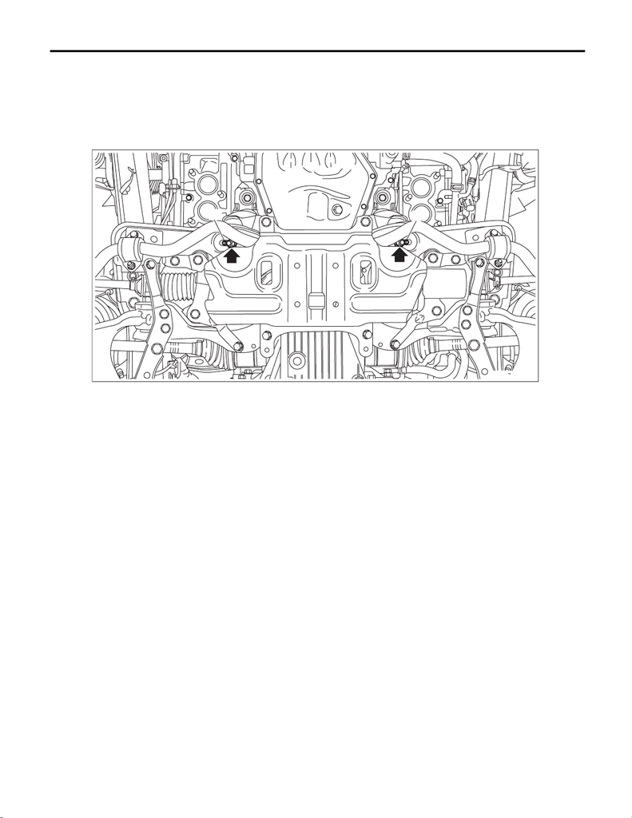

LU(w/o STI)-26

Oil Pan and Strainer

LUBRICATION

13) Install the nuts which hold the engine mounting to the crossmember.

NOTE:

• Use a new nut.

• Make sure that locators (a) of the engine mounting are securely inserted.

Tightening torque:

60 N·m (6.1 kgf-m, 44.3 ft-lb)

14) Install the front exhaust pipe. <Ref. to EX(w/o STI)-19, INSTALLATION, Front Exhaust Pipe.>

15) Install the under cover. <Ref. to EI-22, INSTALLATION, Front Under Cover.>

16) Lower the vehicle.

17) Install the air intake duct. <Ref. to IN(w/o STI)-22, INSTALLATION, Air Intake Duct.>

18) Connect the ground terminal to battery sensor. <Ref. to NT-5, BATTERY, NOTE, Note.>

19) Refill the engine oil. <Ref. to LU(w/o STI)-11, REPLACEMENT, Engine Oil.>

20) Fill engine coolant. <Ref. to CO(w/o STI)-14, FILLING OF ENGINE COOLANT, REPLACEMENT, En-

gine Coolant.>

21) Install the collector cover.

22) Set the front hood to the normal position. <Ref. to NT-20, FRONT HOOD DAMPER STAY, NOTE, Note.>

23) Install the striker - front hood. <Ref. to EB-15, ASSEMBLY, Front Hood.>

24) Close the front hood.

ME-08112

(a)

(a)

15WRX_STI_US_EN.book 26 ページ ２０１５年２月１３日 金曜日 午前１１時２０分

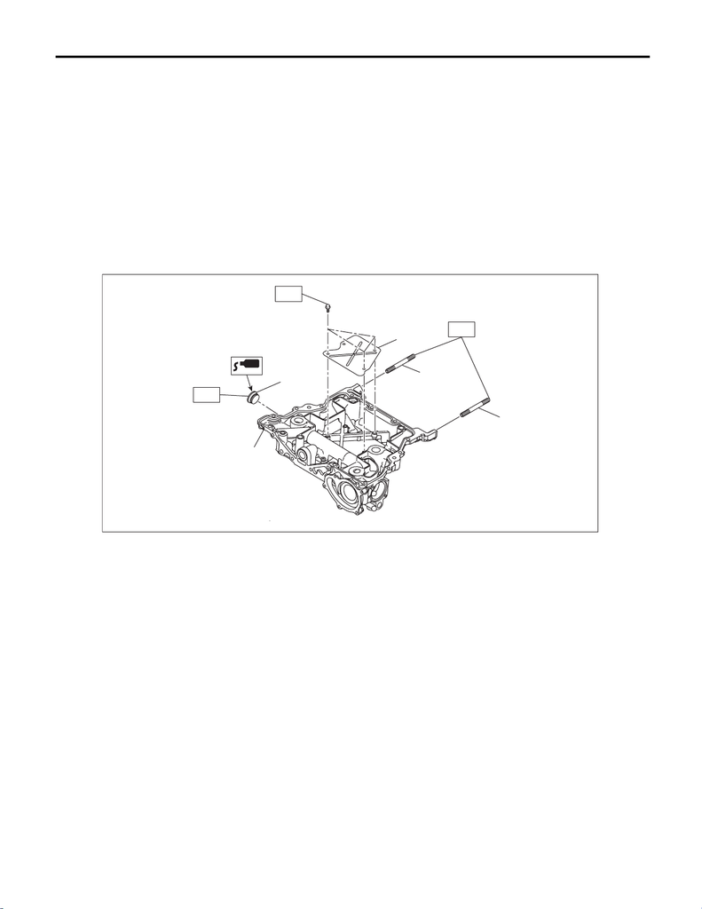

LU(w/o STI)-27

Oil Pan and Strainer

LUBRICATION

2. OIL PAN UPPER

NOTE:

Before installing the oil pan upper, clean the mating surface of oil pan upper and cylinder block.

1) Apply liquid gasket to the plug threads.

Liquid gasket:

THREE BOND 2411 or equivalent

2) Attach the plug to the oil pan upper.

3) Attach the stud bolts to the oil pan upper.

4) Attach the baffle plate to the oil pan upper.

Tightening torque:

T1: 6.4 N·m (0.7 kgf-m, 4.7 ft-lb)

T2: 10 N·m (1.0 kgf-m, 7.4 ft-lb)

T3: 90 N·m (9.2 kgf-m, 66.4 ft-lb)

(A) Oil pan upper (B) Baffle plate (C) Stud bolt

(D) Plug

LU-03216

(B)

(C)

(A)

(D)

(C)

T3

T2

T1

15WRX_STI_US_EN.book 27 ページ ２０１５年２月１３日 金曜日 午前１１時２０分

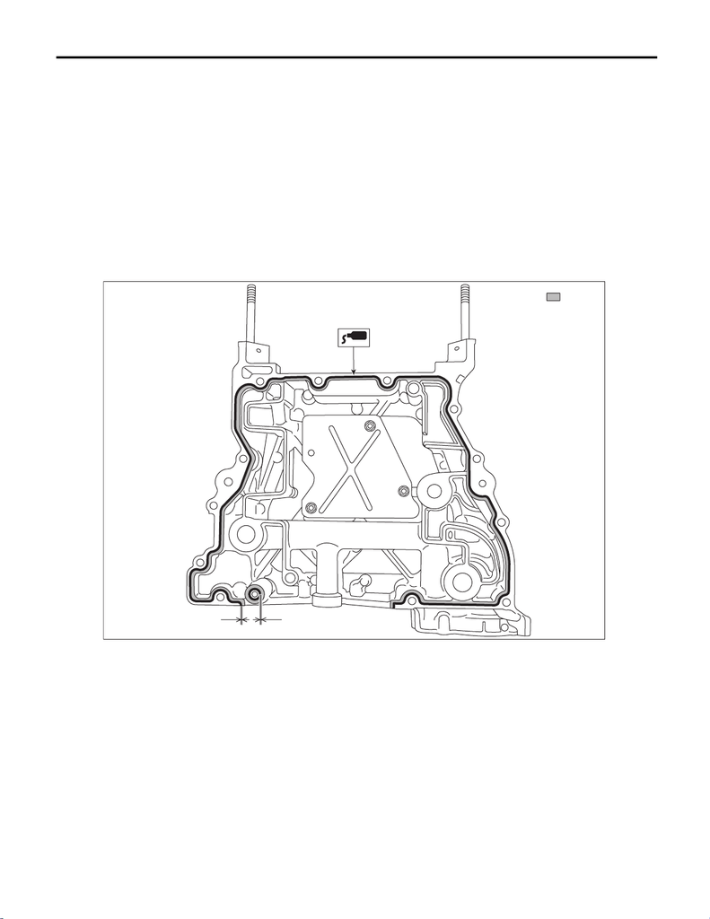

LU(w/o STI)-28

Oil Pan and Strainer

LUBRICATION

5) Apply liquid gasket to the mating surface of the oil pan upper as shown in the figure, and install the oil pan

upper to the cylinder block.

CAUTION:

Be careful not to apply any liquid gasket to the O-ring.

NOTE:

• Use new O-rings.

• Install within 5 min. after applying liquid gasket.

• Apply liquid gasket 1.5 mm (0.0591 in) outside from the chamfer surface. However, application of liquid

gasket on the chamfer surface around the bolt hole is allowed.

Liquid gasket:

THREE BOND 1217G (Part No. K0877Y0100) or equivalent

Liquid gasket applying diameter:

5

±

1 mm (0.1969

±

0.0394 in)

(A) Chamfer surface (B) 1.5 mm (0.0591 in)

ME-07033

(B)

:(A)

(B)

15WRX_STI_US_EN.book 28 ページ ２０１５年２月１３日 金曜日 午前１１時２０分

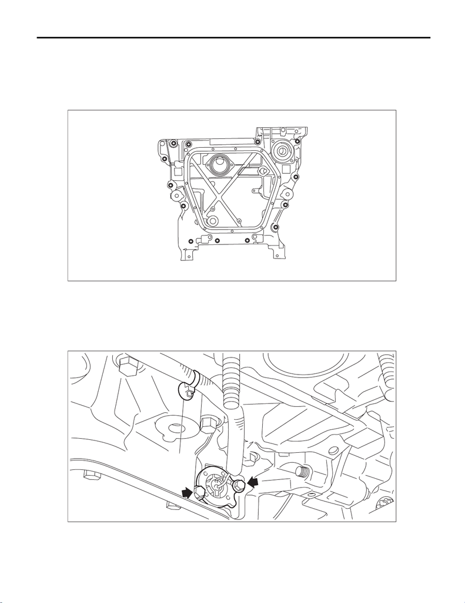

LU(w/o STI)-29

Oil Pan and Strainer

LUBRICATION

6) Tighten the bolts to secure the oil pan upper to the cylinder block in the numerical order.

NOTE:

After tightening, if the liquid gasket is squeezed out onto the seal surface of the chain cover, completely re-

move any squeezed-out liquid gasket.

Tightening torque:

18 N·m (1.8 kgf-m, 13.3 ft-lb)

7) Install the oil level switch on the oil pan upper, and secure the harness with clips (A).

NOTE:

• Use new O-rings.

• Apply a coat of engine oil to the O-rings.

Tightening torque:

6.4 N·m (0.7 kgf-m, 4.7 ft-lb)

8) Install the chain cover. <Ref. to ME(w/o STI)-101, INSTALLATION, Chain Cover.>

9) Install the oil pan and strainer. <Ref. to LU(w/o STI)-21, OIL PAN AND STRAINER, INSTALLATION, Oil

Pan and Strainer.>

10) Install the water pipe assembly. <Ref. to CO(w/o STI)-26, INSTALLATION, Water Pipe Assembly.>

LU-02736

(1)

(2)

(3)

(4)

(5)

(6)

(7)

(8)

(9)

(10)

(11)

(12)

(13)

LU-02912

(A)

15WRX_STI_US_EN.book 29 ページ ２０１５年２月１３日 金曜日 午前１１時２０分

[figure not shown]

LU(w/o STI)-30

Oil Pan and Strainer

LUBRICATION

11) Install the thermostat cover. <Ref. to CO(w/o STI)-34, INSTALLATION, Thermostat.>

12) Install the water pump. <Ref. to CO(w/o STI)-17, INSTALLATION, Water Pump.>

13) Install the engine to the vehicle. <Ref. to ME(w/o STI)-61, INSTALLATION, Engine Assembly.>

14) Refill the engine oil. <Ref. to LU(w/o STI)-11, REPLACEMENT, Engine Oil.>

15) Fill engine coolant. <Ref. to CO(w/o STI)-14, FILLING OF ENGINE COOLANT, REPLACEMENT, En-

gine Coolant.>

C: INSPECTION

Check that the oil pan, oil pan upper, oil strainer and baffle plate do not have deformation, cracks or damage.

15WRX_STI_US_EN.book 30 ページ ２０１５年２月１３日 金曜日 午前１１時２０分